# Practica 2: Limpieza y validación de los datos

Anddy Aldave Valle, Alejandro Pulido Duque

9 de Junio de 2020

## 1. Descripción del dataset. ¿Por qué es importante y qué pregunta/problema pretende responder?

El dataset “Diamonds” ha sido descargado de Kaggle, cuya licencia es *desconocida* tal y como indica el mismo.

> Este Set de datos puede ser descargado de: https://www.kaggle.com/shivam2503/diamonds El set de datos contiene 53940 registros de diamantes. Para cada registro, los campos del conjunto de datos son los siguientes
- x: El número de registro
- carat: Peso en kilates del diamante
- cut: La calidad del corte del diamante
- color: El color del diamante
- clarity: Califica la apariencia visual de cada diamante
- depth: La altura de un diamante, medida desde el culet, o base, hasta la tabla, o tope superior, divido por su diámetro medio (z / media(x, y))
- table: El ancho de la tabla del diamante expresado como un porcentaje de su diámetro medio
- price: El precio del diamante
- x: longitud del diamante en mm
- y: ancho del diamante en mm
- z: profundidad del diamante en mm

Además, se añadirá un atributo secundario que facilitará el análisis. Este atributo secundario, calculado a partir de los descritos en la lista, es:

- Volumen

A continuación, para mayor claridad, se incluyen las partes del diamante, que nos ayudará a localizar los atributos de medida (Altura, Tabla, X, Y, Z)

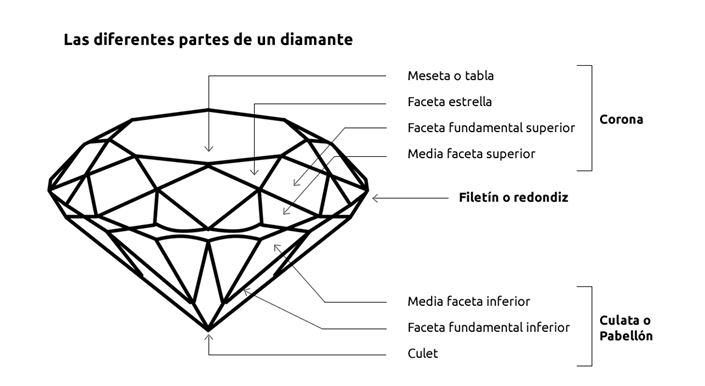

Partes del diamante

Resulta interesante desde un punto de vista de la limpieza y el análisis de los datos obtenidos. En primer lugar, nos permite ejecutar ciertas tareas de limpieza para adecuar los datos a un posterior análisis exhaustivo de las variables.

La principal pregunta que este análisis intentará responder cómo se relacionan las diferentes características físicas de un diamante entre sí, y qué grado de relacion guardan con el precio de cada uno de esos diamantes.

Las características de los atributos disponibles nos permitirán hacer varios estudios, a destacar:

- Correlaciones
- Regresiones de varios tipos
- Hipótesis
- Árboles de clasificación

Todos los modelos son característicos del análisis de datos en la Ciencia de Datos, por tanto, la importancia radica en la usabilidad de este dataset y sus aplicaciones prácticas de los modelos anteriormente mencionados.

## 2. Integración y selección de los datos de interés a analizar.

```r
# Lectura de datos
diamonds_df <- read.csv("diamonds.csv", header = TRUE, sep=",", dec = ".")
#Ejecutando la funcion summary sobre el dataframe, nos mostrará un resumen de cada variable
summary(diamonds_df)
```

```
##        X             carat               cut        color        clarity
##  Min.   :    1   Min.   :0.2000   Fair     : 1610   D: 6775   SI1    :13065
##  1st Qu.:13486   1st Qu.:0.4000   Good     : 4906   E: 9797   VS2    :12258
##  Median :26971   Median :0.7000   Ideal    :21551   F: 9542   SI2    : 9194
##  Mean   :26971   Mean   :0.7979   Premium  :13791   G:11292   VS1    : 8171
##  3rd Qu.:40455   3rd Qu.:1.0400   Very Good:12082   H: 8304   VVS2   : 5066
##  Max.   :53940   Max.   :5.0100                     I: 5422   VVS1   : 3655
##                                                     J: 2808   (Other): 2531
##      depth           table           price             x
##  Min.   :43.00   Min.   :43.00   Min.   :  326   Min.   : 0.000
##  1st Qu.:61.00   1st Qu.:56.00   1st Qu.:  950   1st Qu.: 4.710
##  Median :61.80   Median :57.00   Median : 2401   Median : 5.700
##  Mean   :61.75   Mean   :57.46   Mean   : 3933   Mean   : 5.731
##  3rd Qu.:62.50   3rd Qu.:59.00   3rd Qu.: 5324   3rd Qu.: 6.540
##  Max.   :79.00   Max.   :95.00   Max.   :18823   Max.   :10.740
##
##        y                z
##  Min.   : 0.000   Min.   : 0.000
##  1st Qu.: 4.720   1st Qu.: 2.910
##  Median : 5.710   Median : 3.530
##  Mean   : 5.735   Mean   : 3.539
##  3rd Qu.: 6.540   3rd Qu.: 4.040
##  Max.   :58.900   Max.   :31.800
##
```

```r
str(diamonds_df)
```

```
## 'data.frame':    53940 obs. of  11 variables:
##  $ X      : int  1 2 3 4 5 6 7 8 9 10 ...
##  $ carat  : num  0.23 0.21 0.23 0.29 0.31 0.24 0.24 0.26 0.22 0.23 ...
##  $ cut    : Factor w/ 5 levels "Fair","Good",..: 3 4 2 4 2 5 5 5 1 5 ...
##  $ color  : Factor w/ 7 levels "D","E","F","G",..: 2 2 2 6 7 7 6 5 2 5 ...
##  $ clarity: Factor w/ 8 levels "I1","IF","SI1",..: 4 3 5 6 4 8 7 3 6 5 ...
##  $ depth  : num  61.5 59.8 56.9 62.4 63.3 62.8 62.3 61.9 65.1 59.4 ...
##  $ table  : num  55 61 65 58 58 57 57 55 61 61 ...
##  $ price  : int  326 326 327 334 335 336 336 337 337 338 ...
##  $ x      : num  3.95 3.89 4.05 4.2 4.34 3.94 3.95 4.07 3.87 4 ...
##  $ y      : num  3.98 3.84 4.07 4.23 4.35 3.96 3.98 4.11 3.78 4.05 ...
##  $ z      : num  2.43 2.31 2.31 2.63 2.75 2.48 2.47 2.53 2.49 2.39 ...
```

La lectura del fichero y el resumen de estadísticos de las variables nos muestra que el conjunto de datos consta de 53940 registros y 11 variables o columnas.

La función de importación del fichero csv ha asignado correctamente cada variable con su tipo de datos, los que tienen decimales son números, los que son cualitativos se han importado como factores y el precio es un número entero

De todas ellas la variable X no aporta nada, ya que contiene el número o identificador de registro, por ello, la eliminaremos del conjunto de datos

```r
diamonds_df<-diamonds_df[,-1]
```

Consideramos que necesitamos una variable que contenga el volumen de los diamantes, basándonos en sus medidas x, y, z

```r
volume<-diamonds_df$x*diamonds_df$y*diamonds_df$z
diamonds_df<-cbind(diamonds_df,volume)
```

## 3. Limpieza de los datos.

Antes de proceder con la evaluación de ceros o elementos vacíos, se va a realizar una limpieza de datos duplicados. En primer lugar, veamos si tenemos duplicidades en nuestros datos:

```r
nrow(diamonds_df[duplicated(diamonds_df), ])
```

```
## [1] 146
```

Vemos que tenemos 146 registros duplicados, vamos a proceder a su eliminación, ya que para nuestro estudio posterior, podrían alterar los resultados.

```r
suppressWarnings(suppressMessages(library(dplyr)))

diamonds_df<-distinct(diamonds_df)
```

Volvemos a comprobar

```r
nrow(diamonds_df[duplicated(diamonds_df), ])
```

```
## [1] 0
```

Ya podríamos continuar con el análisis.

### 3.1. ¿Los datos contienen ceros o elementos vacíos? ¿Cómo gestionarías cada uno de estos casos?

```r
#Comprobamos si hay registros con elementos vacíos o NA
sapply(diamonds_df, anyNA)
```

```
##   carat     cut   color clarity   depth   table   price       x       y       z
##   FALSE   FALSE   FALSE   FALSE   FALSE   FALSE   FALSE   FALSE   FALSE   FALSE
##  volume
##   FALSE
```

Hemos comprobado que no hay ningún registro con elementos vacíos

```r
#Comprobamos si hay registros que contienen ceros
sapply(diamonds_df, function(x) any(x==0))
```

```
##   carat     cut   color clarity   depth   table   price       x       y       z
##   FALSE   FALSE   FALSE   FALSE   FALSE   FALSE   FALSE    TRUE    TRUE    TRUE
##  volume
##    TRUE
```

Hemos comprobado que las variables volumen, x, y, z contienen ceros

Un diamante es un objeto que debe tener ancho, altura y profundidad, por lo tanto, asumimos que si alguna de estas variables son 0, es que no se ha medido o hay un error en los datos.

Este tipo de problemas, tiene 2 soluciones: Podríamos eliminar estos registros o calcular un nuevo valor según la semejanza de este registro con otros dentro del mismo conjunto de datos.

Creemos que eliminar estos registros limitaría nuestro conjunto de datos y ocultaría información que queremos analizar, por ello, imputaremos los valores perdidos a través del modelo basado en los k-vecinos más cercanos.

El modelo Knn encuentra los k vecinos más cercanos según la semejanza de los registros perdidos con los demás registros del juego de datos.

Solo imputaremos el valor en las variables x, y, z, no tiene sentido aplicar este método a la variable volumen, ya que, es un campo calculado, lo que haremos será que después de calcular los nuevos valores, volveremos a calcular el volumen.

```r
suppressWarnings(suppressMessages(library(VIM)))
library(VIM)
#Miramos que registros contienen ceros
indicesx <-which(diamonds_df$x==0)
indicesy <-which(diamonds_df$y==0)
indicesz <-which(diamonds_df$z==0)
#Asignamos el valor de NA a todos los campos que contienen ceros
diamonds_df[indicesx,"x"]<-NA
diamonds_df[indicesy,"y"]<-NA
diamonds_df[indicesz,"z"]<-NA
```

Miramos el estado de los registros que contienen ceros en la variable x, antes de la imputación

```r
diamonds_df[indicesx,]
```

```
##       carat       cut color clarity depth table price  x    y  z volume
## 11157  1.07     Ideal     F     SI2  61.6    56  4954 NA 6.62 NA      0
## 11936  1.00 Very Good     H     VS2  63.3    53  5139 NA   NA NA      0
## 15915  1.14      Fair     G     VS1  57.5    67  6381 NA   NA NA      0
## 24465  1.56     Ideal     G     VS2  62.2    54 12800 NA   NA NA      0
## 26184  1.20   Premium     D    VVS1  62.1    59 15686 NA   NA NA      0
## 27365  2.25   Premium     H     SI2  62.8    59 18034 NA   NA NA      0
## 49414  0.71      Good     F     SI2  64.1    60  2130 NA   NA NA      0
```

```r
kNNx<-kNN(diamonds_df[,c("cut","color","clarity","depth","table","price","x","y","z")], variable="x",k=3)
diamonds_df[indicesx,"x"]<-kNNx[indicesx,"x"]
```

Después de la imputación en la variable x

```r
diamonds_df[indicesx,]
```

```
##       carat       cut color clarity depth table price    x    y  z volume
## 11157  1.07     Ideal     F     SI2  61.6    56  4954 6.50 6.62 NA      0
## 11936  1.00 Very Good     H     VS2  63.3    53  5139 6.61   NA NA      0
## 15915  1.14      Fair     G     VS1  57.5    67  6381 6.32   NA NA      0
## 24465  1.56     Ideal     G     VS2  62.2    54 12800 7.34   NA NA      0
## 26184  1.20   Premium     D    VVS1  62.1    59 15686 7.01   NA NA      0
## 27365  2.25   Premium     H     SI2  62.8    59 18034 8.42   NA NA      0
## 49414  0.71      Good     F     SI2  64.1    60  2130 6.50   NA NA      0
```

Miramos el estado de los registros que contienen ceros en la variable y, antes de la imputación

```r
diamonds_df[indicesy,]
```

```
##       carat       cut color clarity depth table price    x  y  z volume
## 11936  1.00 Very Good     H     VS2  63.3    53  5139 6.61 NA NA      0
## 15915  1.14      Fair     G     VS1  57.5    67  6381 6.32 NA NA      0
## 24465  1.56     Ideal     G     VS2  62.2    54 12800 7.34 NA NA      0
## 26184  1.20   Premium     D    VVS1  62.1    59 15686 7.01 NA NA      0
## 27365  2.25   Premium     H     SI2  62.8    59 18034 8.42 NA NA      0
## 49414  0.71      Good     F     SI2  64.1    60  2130 6.50 NA NA      0
```

```r
kNNy<-kNN(diamonds_df[,c("cut","color","clarity","depth","table","price","x","y","z")], variable="y",k=3)
diamonds_df[indicesy,"y"]<-kNNy[indicesy,"y"]
```

Después de la imputación en la variable y

```r
diamonds_df[indicesy,]
```

```
##       carat       cut color clarity depth table price    x    y  z volume
## 11936  1.00 Very Good     H     VS2  63.3    53  5139 6.61 6.54 NA      0
## 15915  1.14      Fair     G     VS1  57.5    67  6381 6.32 6.19 NA      0
## 24465  1.56     Ideal     G     VS2  62.2    54 12800 7.34 7.31 NA      0
## 26184  1.20   Premium     D    VVS1  62.1    59 15686 7.01 6.88 NA      0
## 27365  2.25   Premium     H     SI2  62.8    59 18034 8.42 8.37 NA      0
## 49414  0.71      Good     F     SI2  64.1    60  2130 6.50 6.47 NA      0
```

Miramos el estado de los registros que contienen ceros en la variable z, antes de la imputación

```r
diamonds_df[indicesz,]
```

```
##       carat       cut color clarity depth table price    x    y  z volume
## 2202   1.00   Premium     G     SI2  59.1    59  3142 6.55 6.48 NA      0
## 2309   1.01   Premium     H      I1  58.1    59  3167 6.66 6.60 NA      0
## 4779   1.10   Premium     G     SI2  63.0    59  3696 6.50 6.47 NA      0
## 5458   1.01   Premium     F     SI2  59.2    58  3837 6.50 6.47 NA      0
## 10146  1.50      Good     G      I1  64.0    61  4731 7.15 7.04 NA      0
## 11157  1.07     Ideal     F     SI2  61.6    56  4954 6.50 6.62 NA      0
## 11936  1.00 Very Good     H     VS2  63.3    53  5139 6.61 6.54 NA      0
## 13571  1.15     Ideal     G     VS2  59.2    56  5564 6.88 6.83 NA      0
## 15915  1.14      Fair     G     VS1  57.5    67  6381 6.32 6.19 NA      0
## 24339  2.18   Premium     H     SI2  59.4    61 12631 8.49 8.45 NA      0
## 24465  1.56     Ideal     G     VS2  62.2    54 12800 7.34 7.31 NA      0
## 26064  2.25   Premium     I     SI1  61.3    58 15397 8.52 8.42 NA      0
## 26184  1.20   Premium     D    VVS1  62.1    59 15686 7.01 6.88 NA      0
## 27048  2.20   Premium     H     SI1  61.2    59 17265 8.42 8.37 NA      0
## 27365  2.25   Premium     H     SI2  62.8    59 18034 8.42 8.37 NA      0
## 27439  2.02   Premium     H     VS2  62.7    53 18207 8.02 7.95 NA      0
## 27673  2.80      Good     G     SI2  63.8    58 18788 8.90 8.85 NA      0
## 49414  0.71      Good     F     SI2  64.1    60  2130 6.50 6.47 NA      0
## 51362  1.12   Premium     G      I1  60.4    59  2383 6.71 6.67 NA      0
```

```r
kNNz<-kNN(diamonds_df[,c("cut","color","clarity","depth","table","price","x","y","z")], variable="z",k=3)
diamonds_df[indicesz,"z"]<-kNNz[indicesz,"z"]
```

Después de la imputación en la variable z

```r
diamonds_df[indicesz,]
```

```
##       carat       cut color clarity depth table price    x    y    z volume
## 2202   1.00   Premium     G     SI2  59.1    59  3142 6.55 6.48 3.86      0
## 2309   1.01   Premium     H      I1  58.1    59  3167 6.66 6.60 4.05      0
## 4779   1.10   Premium     G     SI2  63.0    59  3696 6.50 6.47 4.05      0
## 5458   1.01   Premium     F     SI2  59.2    58  3837 6.50 6.47 3.82      0
## 10146  1.50      Good     G      I1  64.0    61  4731 7.15 7.04 4.63      0
## 11157  1.07     Ideal     F     SI2  61.6    56  4954 6.50 6.62 3.99      0
## 11936  1.00 Very Good     H     VS2  63.3    53  5139 6.61 6.54 4.14      0
## 13571  1.15     Ideal     G     VS2  59.2    56  5564 6.88 6.83 3.96      0
## 15915  1.14      Fair     G     VS1  57.5    67  6381 6.32 6.19 3.79      0
## 24339  2.18   Premium     H     SI2  59.4    61 12631 8.49 8.45 5.09      0
## 24465  1.56     Ideal     G     VS2  62.2    54 12800 7.34 7.31 4.55      0
## 26064  2.25   Premium     I     SI1  61.3    58 15397 8.52 8.42 5.02      0
## 26184  1.20   Premium     D    VVS1  62.1    59 15686 7.01 6.88 4.16      0
## 27048  2.20   Premium     H     SI1  61.2    59 17265 8.42 8.37 5.13      0
## 27365  2.25   Premium     H     SI2  62.8    59 18034 8.42 8.37 5.23      0
## 27439  2.02   Premium     H     VS2  62.7    53 18207 8.02 7.95 5.06      0
## 27673  2.80      Good     G     SI2  63.8    58 18788 8.90 8.85 5.10      0
## 49414  0.71      Good     F     SI2  64.1    60  2130 6.50 6.47 3.83      0
## 51362  1.12   Premium     G      I1  60.4    59  2383 6.71 6.67 4.02      0
```

calculamos nuevamente la variable volumen ya que, esta depende de los valores de x, y, z

```r
diamonds_df$volume<-diamonds_df$x*diamonds_df$y*diamonds_df$z
```

Finalmente, volvemos a comprobar si hay registros ceros o elementos vacíos

```r
#Comprobamos si hay registros con elementos vacíos o NA
sapply(diamonds_df, anyNA)
```

```
##   carat     cut   color clarity   depth   table   price       x       y       z
##   FALSE   FALSE   FALSE   FALSE   FALSE   FALSE   FALSE   FALSE   FALSE   FALSE
##  volume
##   FALSE
```

```r
#Comprobamos si hay registros que contienen ceros
sapply(diamonds_df, function(x) any(x==0))
```

```
##   carat     cut   color clarity   depth   table   price       x       y       z
##   FALSE   FALSE   FALSE   FALSE   FALSE   FALSE   FALSE   FALSE   FALSE   FALSE
##  volume
##   FALSE
```

Efectivamente, ya no hay ningún valor cero ni elementos vacío

### 3.2 Identificación y tratamiento de valores extremos.

En primer lugar, en esta categoría analizaremos sólo los valores numéricos, para ello, vamos a realizar representaciones de tipo caja de cada una de las variables.

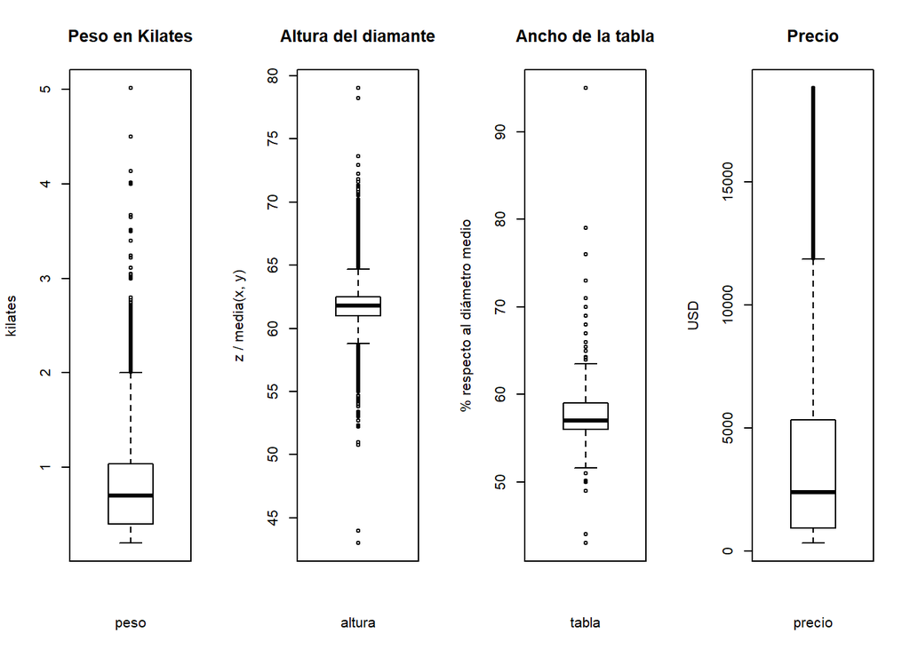

```r
#Representamos cada variable
par (mfrow= c (1,4) )
boxplot(diamonds_df$carat, main="Peso en Kilates", xlab="peso", ylab="kilates")
boxplot(diamonds_df$depth, main="Altura del diamante", xlab="altura", ylab="z / media(x, y)")
boxplot(diamonds_df$table, main="Ancho de la tabla", xlab="tabla", ylab="% respecto al diámetro medio")
boxplot(diamonds_df$price, main="Precio", xlab="precio", ylab="USD")
```

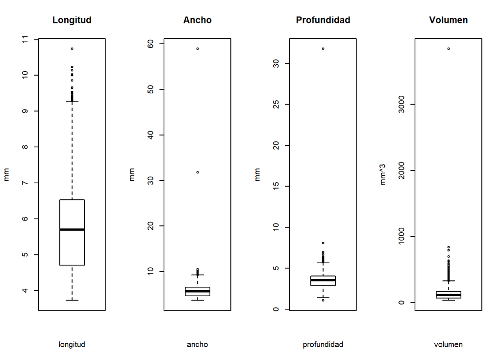

```r
par (mfrow= c (1,4))
boxplot(diamonds_df$x, main="Longitud", xlab="longitud", ylab="mm")
boxplot(diamonds_df$y, main="Ancho", xlab="ancho", ylab="mm")
boxplot(diamonds_df$z, main="Profundidad", xlab="profundidad", ylab="mm")
boxplot(diamonds_df$volume, main="Volumen", xlab="volumen", ylab="mm^3")
```

```r
preciomax<-max(diamonds_df$price)
volumenmax<-max(diamonds_df$volume)
cat("El precio máximo registrado es: ",preciomax, "\n El volumen máximo registrado es: ", volumenmax)
```

```
## El precio máximo registrado es:  18823
##  El volumen máximo registrado es:  3840.598
```

```r
diamonds_df[diamonds_df$price==preciomax,]
```

```
##       carat     cut color clarity depth table price   x    y    z   volume
## 27683  2.29 Premium     I     VS2  60.8    60 18823 8.5 8.47 5.16 371.4942
```

Evaluaremos los máximos de la Carat, Precio, “X”,“Y”,“Z”, Tabla, profundidad y Volumen, ya que, según los gráficos muestran los valores extremos más acusados.

En primer lugar, vamos a filtrar por los valores máximos de Peso, tabla, “X”, “Y”, “Z” y Volumen (variables que, como veremos más adelante, están fuertemenete correlacionadas).

```r
diamonds_df[diamonds_df$carat==max(diamonds_df$carat)|diamonds_df$table==max(diamonds_df$table)|diamonds_df$depth==max(diamonds_df$depth)|diamonds_df$volume==max(diamonds_df$volume)|diamonds_df$x==max(diamonds_df$x)|diamonds_df$y==max(diamonds_df$y)|diamonds_df$z==max(diamonds_df$z),c(1,5,6,7,8,9,10,11)]
```

```
##       carat depth table price     x     y     z    volume
## 24013  2.00  58.9  57.0 12210  8.09 58.90  8.06 3840.5981
## 24876  2.01  58.6  95.0 13387  8.32  8.31  4.87  336.7079
## 27351  5.01  65.5  59.0 18018 10.74 10.54  6.98  790.1332
## 48269  0.51  61.8  54.7  1970  5.12  5.15 31.80  838.5024
## 52716  0.50  79.0  73.0  2579  5.21  5.18  4.09  110.3801
```

Además, en el caso de la Profundidad y la tabla, como veremos a continuación, son variables con correlación negativa, esto es, inversamente proporcionales, por tanto, el máximo que encontramos en Profundidad y Tabla tampoco tendrían sentido, observando los datos en su contexto, comparados con el peso, volumen y el precio.

Vamos a continuar analizando las variables Tabla, Profundidad y ancho (“Y”):

```r
suppressWarnings(suppressMessages(library(tidyverse)))
library(tidyverse)
diamonds_df %>% top_n(n=5, y)
```

```
##   carat     cut color clarity depth table price     x     y    z    volume
## 1  2.00 Premium     H     SI2  58.9    57 12210  8.09 58.90 8.06 3840.5981
## 2  4.01 Premium     I      I1  61.0    61 15223 10.14 10.10 6.17  631.8944
## 3  5.01    Fair     J      I1  65.5    59 18018 10.74 10.54 6.98  790.1332
## 4  4.50    Fair     J      I1  65.8    58 18531 10.23 10.16 6.72  698.4553
## 5  0.51   Ideal     E     VS1  61.8    55  2075  5.15 31.80 5.12  838.5024
```

En Y, tenemos otro máximo que no tiene ningún sentido, procedemos al borrado.

```r
diamonds_df[diamonds_df$y==31.8, ]
```

```
##       carat   cut color clarity depth table price    x    y    z   volume
## 49048  0.51 Ideal     E     VS1  61.8    55  2075 5.15 31.8 5.12 838.5024
```

Por otra parte, con el resto de variables no se encuentran más incosistencias.

```r
diamonds_df %>% top_n(n=5, table)
```

```
##   carat  cut color clarity depth table price    x    y    z    volume
## 1  2.01 Fair     F     SI1  58.6    95 13387 8.32 8.31 4.87 336.70790
## 2  0.70 Fair     H     VS1  62.0    73  2100 5.65 5.54 3.47 108.61447
## 3  0.81 Fair     F     SI2  68.8    79  2301 5.26 5.20 3.58  97.92016
## 4  0.79 Fair     G     SI1  65.3    76  2362 5.52 5.13 3.35  94.86396
## 5  0.71 Fair     D     VS2  55.6    73  2368 6.01 5.96 3.33 119.27927
## 6  0.50 Fair     E     VS2  79.0    73  2579 5.21 5.18 4.09 110.38010
```

```r
diamonds_df %>% top_n(n=5, depth)
```

```
##   carat  cut color clarity depth table price    x    y    z   volume
## 1  1.03 Fair     E      I1  78.2    54  1262 5.72 5.59 4.42 141.3286
## 2  0.99 Fair     J      I1  73.6    60  1789 6.01 5.80 4.35 151.6323
## 3  0.96 Fair     G     SI2  72.2    56  2438 6.01 5.81 4.28 149.4495
## 4  0.50 Fair     E     VS2  79.0    73  2579 5.21 5.18 4.09 110.3801
## 5  0.90 Fair     G     SI1  72.9    54  2691 5.74 5.67 4.16 135.3905
```

Para corregir lo anterior, se van a proceder a borrar los datos que registran máximos incoherentes.

```r
diamonds_df<-diamonds_df[-c(24013, 24876, 48269, 52716, 49048), ]
```

Comprobamos de nuevo cómo han quedado las variables de las que hemos eliminado valores extremos:

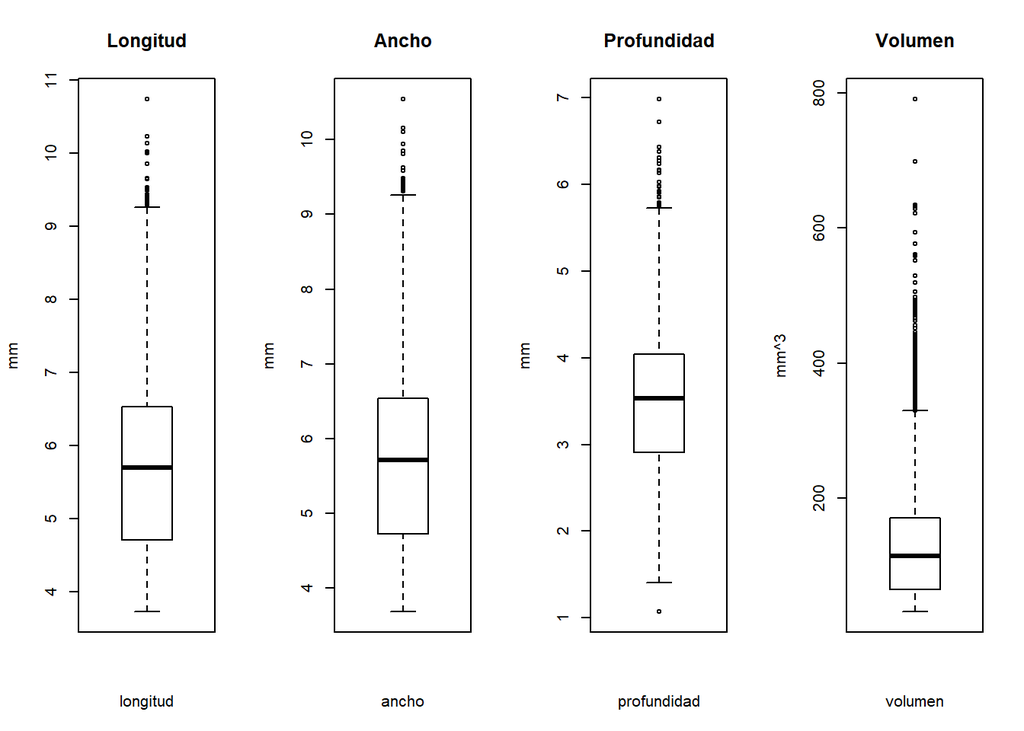

```r
par (mfrow= c (1,4))
boxplot(diamonds_df$x, main="Longitud", xlab="longitud", ylab="mm")
boxplot(diamonds_df$y, main="Ancho", xlab="ancho", ylab="mm")
boxplot(diamonds_df$z, main="Profundidad", xlab="profundidad", ylab="mm")
boxplot(diamonds_df$volume, main="Volumen", xlab="volumen", ylab="mm^3")
```

Quedando, sin lugar a dudas, mucho más coherente.

Recordemos el valor que indica el máximo que vemos en las 4 gráficas:

```r
diamonds_df[diamonds_df$volume==max(diamonds_df$volume), ]
```

```
##       carat  cut color clarity depth table price     x     y    z   volume
## 27351  5.01 Fair     J      I1  65.5    59 18018 10.74 10.54 6.98 790.1332
```

## 4. Análisis de los datos.

### 4.1. Selección de los grupos de datos que se quieren analizar/comparar (planificación de los análisis a aplicar).

Vamos a realizar un análisis que responderá cómo están relacionadas las principales características de un diamante.

Las características que analizaremos son:

• El precio

• El volumen

• Los tipos de corte : Good y Premium

• El color

• La apariencia visual

Los estudios y pruebas que realizaremos sobre los atributos disponibles del conjunto de datos serán:

• Correlaciones

• Regresiones de varios tipos

• Hipótesis

• Árboles de clasiﬁcación

### 4.2. Comprobación de la normalidad y homogeneidad de la varianza.

#### 4.2.1. Normalidad en variables numéricas

En primer lugar, se realiza un estudio sobre la normalidad de las variables precio, altura, tabla, x, y, z y volumen.

Se realizará un estudio visual y, a continuación, un test Shapiro (considerado de los más potentes para el contraste de la normalidad).

En el estudio visual se utilizarán histogramas de frecuencias relativas con curva de normalidad superpuesta

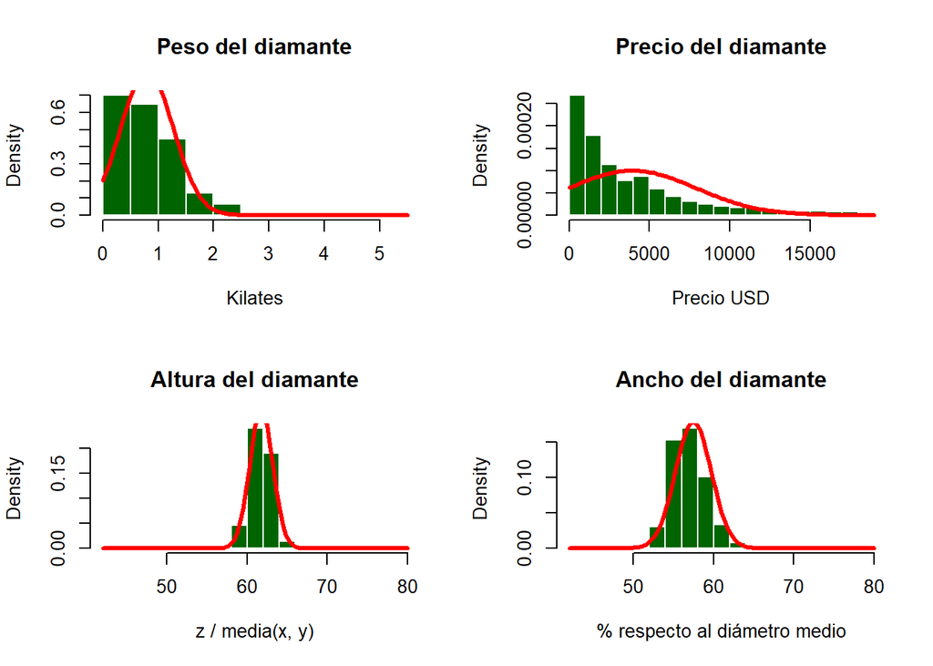

```r
par(mfrow=c(2,2))
#Variable peso
hist(diamonds_df$carat, main= "Peso del diamante", freq = FALSE, xlab = "Kilates", col = "dark green", border="white")
curve(dnorm(x, mean=mean(diamonds_df$carat), sd=sd(diamonds_df$carat)), add=TRUE, col="red", lwd=3)
#Variable precio
hist(diamonds_df$price, main= "Precio del diamante", freq = FALSE, xlab = "Precio USD", col = "dark green", border="white")
curve(dnorm(x, mean=mean(diamonds_df$price), sd=sd(diamonds_df$price)), add=TRUE, col="red", lwd=3)
#Variable altura
hist(diamonds_df$depth, main= "Altura del diamante", freq = FALSE, xlab = "z / media(x, y)", col = "dark green", border="white")
curve(dnorm(x, mean=mean(diamonds_df$depth), sd=sd(diamonds_df$depth)), add=TRUE, col="red", lwd=3)
#Variable ancho
hist(diamonds_df$table, main= "Ancho del diamante", freq = FALSE, xlab = "% respecto al diámetro medio", col = "dark green", border="white")
curve(dnorm(x, mean=mean(diamonds_df$table), sd=sd(diamonds_df$table)), add=TRUE, col="red", lwd=3)
```

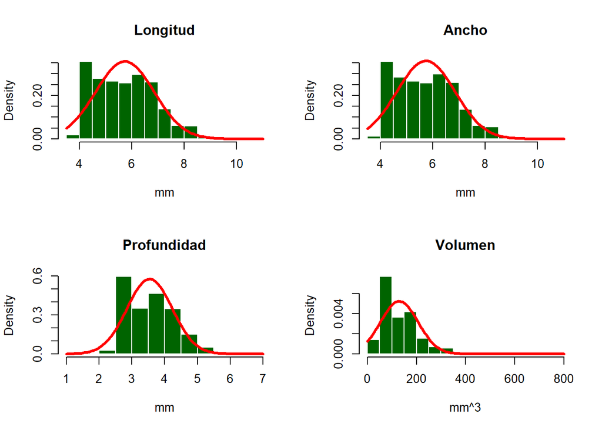

```r
par(mfrow=c(2,2))
#Variable "x"
hist(diamonds_df$x, main= "Longitud", freq = FALSE, xlab = "mm", col = "dark green", border="white")
curve(dnorm(x, mean=mean(diamonds_df$x), sd=sd(diamonds_df$x)), add=TRUE, col="red", lwd=3)
#Variable "y"
hist(diamonds_df$y, main= "Ancho", freq = FALSE, xlab = "mm", col = "dark green", border="white")
curve(dnorm(x, mean=mean(diamonds_df$y), sd=sd(diamonds_df$y)), add=TRUE, col="red", lwd=3)
#Variable z"
hist(diamonds_df$z, main= "Profundidad", freq = FALSE, xlab = "mm", col = "dark green", border="white")
curve(dnorm(x, mean=mean(diamonds_df$z), sd=sd(diamonds_df$z)), add=TRUE, col="red", lwd=3)
#Volumen
hist(diamonds_df$volume, main= "Volumen", freq = FALSE, xlab = "mm^3", col = "dark green", border="white")
curve(dnorm(x, mean=mean(diamonds_df$volume), sd=sd(diamonds_df$volume)), add=TRUE, col="red", lwd=3)
```

Vemos que en el caso del precio seguiría una distribución exponencial negativa, por otra parte, la longitud no seguiría ninguna distribución apreciable.

Vamos a realizar el Test Shapiro a las variables que podrían asemejarse a una distribución normal, si atendemos a su gráfico.

```r
shapiro.test(diamonds_df$carat[1:5000])
```

```
##
##  Shapiro-Wilk normality test
##
## data:  diamonds_df$carat[1:5000]
## W = 0.90915, p-value < 2.2e-16
```

```r
shapiro.test(diamonds_df$depth[1:5000])
```

```
##
##  Shapiro-Wilk normality test
##
## data:  diamonds_df$depth[1:5000]
## W = 0.95418, p-value < 2.2e-16
```

```r
shapiro.test(diamonds_df$table[1:5000])
```

```
##
##  Shapiro-Wilk normality test
##
## data:  diamonds_df$table[1:5000]
## W = 0.95044, p-value < 2.2e-16
```

```r
shapiro.test(diamonds_df$y[1:5000])
```

```
##
##  Shapiro-Wilk normality test
##
## data:  diamonds_df$y[1:5000]
## W = 0.82562, p-value < 2.2e-16
```

```r
shapiro.test(diamonds_df$z[1:5000])
```

```
##
##  Shapiro-Wilk normality test
##
## data:  diamonds_df$z[1:5000]
## W = 0.85945, p-value < 2.2e-16
```

```r
shapiro.test(diamonds_df$volume[1:5000])
```

```
##
##  Shapiro-Wilk normality test
##
## data:  diamonds_df$volume[1:5000]
## W = 0.90739, p-value < 2.2e-16
```

Como vemos, la distribución de ningún atributo es normal.

#### 4.2.2. Normalidad en variables categóricas

De manera adicional, vamos a realizar un estudio de normalidad sobre una variable categórica, en este caso, la variable corte, para ello vamos a asignar un valor numérico a cada uno de los niveles de la variable categorica “cut”.

```r
table(diamonds_df$cut)
```

```
##
##      Fair      Good     Ideal   Premium Very Good
##      1596      4891     21487     13747     12068
```

```r
level.cut<-diamonds_df$cut
level.cut[level.cut="Fair"]<-"1"
level.cut[level.cut="Good"]<-"2"
level.cut[level.cut="Very Good"]<-"3"
level.cut[level.cut="Premium"]<-"4"
level.cut[level.cut="Ideal"]<-"5"
```

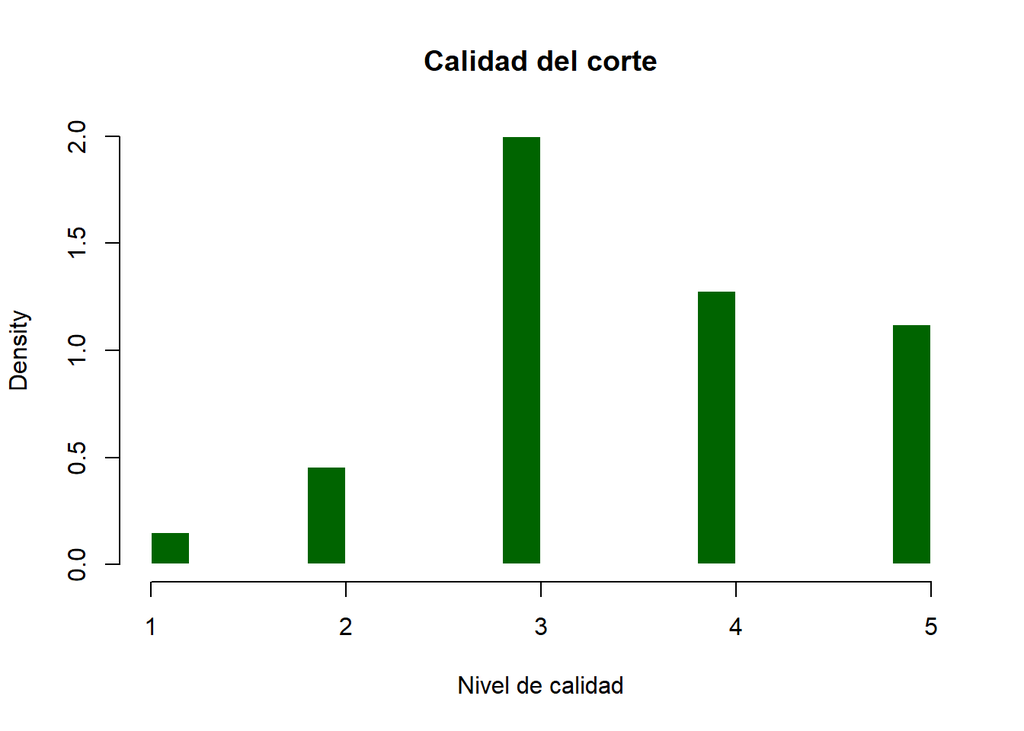

```r
level.cut<-as.numeric(level.cut)
#Variable corte
hist(level.cut, main= "Calidad del corte", freq = FALSE, xlab = "Nivel de calidad", col = "dark green", border="white")
```

```r
#curve(dnorm(x, mean=mean(level.cut), sd=sd(level.cut)), add=TRUE, col="red", lwd=3)
#Test Shapiro
shapiro.test(level.cut[1:5000])
```

```
##
##  Shapiro-Wilk normality test
##
## data:  level.cut[1:5000]
## W = 0.89186, p-value < 2.2e-16
```

Y tampoco podemos afirmar que sea normal.

#### 4.2.2. Análisis de la varianza en variables numéricas en función de la variable “Corte”

A continuación, vamos a comprobar si la varianza es homogénea para las variables numéricas, es decir, cumple con el principio de homocedasticidad, para ello, ya que las muestras no son normales, vamos a utilizar el test de Fligner-Killeen en función de los diferentes niveles de corte para las variables “Precio”, “Volumen” y “Peso”.

##### 4.2.2.1 “Precio” en función de “Corte”

```r
a1 <- diamonds_df[diamonds_df$cut == "Fair","price"]
a2 <- diamonds_df[diamonds_df$cut == "Good","price"]
a3 <- diamonds_df[diamonds_df$cut == "Very Good","price"]
a4 <- diamonds_df[diamonds_df$cut == "Premium","price"]
a5 <- diamonds_df[diamonds_df$cut == "Ideal","price"]
```

Aplicamos el test de Fligner-Killeen

```r
fligner.test(x=list(a1,a2,a3,a4,a5))
```

```
##
##  Fligner-Killeen test of homogeneity of variances
##
## data:  list(a1, a2, a3, a4, a5)
## Fligner-Killeen:med chi-squared = 1657.6, df = 4, p-value < 2.2e-16
```

Su varianza no es constante.

##### 4.2.2.2 “Peso” en función de “Corte”

```r
b1 <- diamonds_df[diamonds_df$cut == "Fair","carat"]
b2 <- diamonds_df[diamonds_df$cut == "Good","carat"]
b3 <- diamonds_df[diamonds_df$cut == "Very Good","carat"]
b4 <- diamonds_df[diamonds_df$cut == "Premium","carat"]
b5 <- diamonds_df[diamonds_df$cut == "Ideal","carat"]
```

Aplicamos el test de Fligner-Killeen

```r
fligner.test(x=list(b1,b2,b3,b4,b5))
```

```
##
##  Fligner-Killeen test of homogeneity of variances
##
## data:  list(b1, b2, b3, b4, b5)
## Fligner-Killeen:med chi-squared = 1156.8, df = 4, p-value < 2.2e-16
```

La varianza no es constante

##### 4.2.2.3 “Volumen” en función de “Corte”

```r
c1 <- diamonds_df[diamonds_df$cut == "Fair","volume"]
c2 <- diamonds_df[diamonds_df$cut == "Good","volume"]
c3 <- diamonds_df[diamonds_df$cut == "Very Good","volume"]
c4 <- diamonds_df[diamonds_df$cut == "Premium","volume"]
c5 <- diamonds_df[diamonds_df$cut == "Ideal","volume"]
```

Aplicamos el test de Fligner-Killeen

```r
fligner.test(x=list(c1,c2,c3,c4,c5))
```

```
##
##  Fligner-Killeen test of homogeneity of variances
##
## data:  list(c1, c2, c3, c4, c5)
## Fligner-Killeen:med chi-squared = 1152.5, df = 4, p-value < 2.2e-16
```

Su varianza no es constante

#### 4.2.3. Otros análisis de la Varianza

Como no hemos obtenido resultados satisfactorios para ninguna de las variables, volvemos a repetir el análisis para otros parámetros. Veamos la varianza del “Precio” en función del “Color” y en función de la “Claridad”

##### 4.2.3.1. “Precio” en función del “Color”

Los diferentes niveles de la variable “Color” son los siguientes:

```r
table(diamonds_df$color)
```

```
##
##     D     E     F     G     H     I     J
##  6755  9773  9519 11262  8271  5407  2802
```

Procedemos de igual modo al anterior:

```r
d1 <- diamonds_df[diamonds_df$color == "D","price"]
d2 <- diamonds_df[diamonds_df$color == "E","price"]
d3 <- diamonds_df[diamonds_df$color == "F","price"]
d4 <- diamonds_df[diamonds_df$color == "G","price"]
d5 <- diamonds_df[diamonds_df$color == "H","price"]
d6 <- diamonds_df[diamonds_df$color == "I","price"]
d7 <- diamonds_df[diamonds_df$color == "J","price"]
```

Aplicamos el test de Fligner-Killeen

```r
fligner.test(x=list(d1,d2,d3,d4,d5,d6,d7))
```

```
##
##  Fligner-Killeen test of homogeneity of variances
##
## data:  list(d1, d2, d3, d4, d5, d6, d7)
## Fligner-Killeen:med chi-squared = 2730.5, df = 6, p-value < 2.2e-16
```

Y seguimos sin tener homocedasticidad

Los diferentes niveles de la variable “Claridad” son los siguientes:

```r
table(diamonds_df$clarity)
```

```
##
##    I1    IF   SI1   SI2   VS1   VS2  VVS1  VVS2
##   740  1784 13031  9149  8154 12228  3647  5056
```

Procedemos de igual modo al anterior:

```r
e1 <- diamonds_df[diamonds_df$clarity == "I1","price"]
e2 <- diamonds_df[diamonds_df$clarity == "IF","price"]
e3 <- diamonds_df[diamonds_df$clarity == "SI1","price"]
e4 <- diamonds_df[diamonds_df$clarity == "SI2","price"]
e5 <- diamonds_df[diamonds_df$clarity == "VS1","price"]
e6 <- diamonds_df[diamonds_df$clarity == "VS2","price"]
e7 <- diamonds_df[diamonds_df$clarity == "VVS1","price"]
e8 <- diamonds_df[diamonds_df$clarity == "VVS2","price"]
```

Aplicamos el test de Fligner-Killeen

```r
fligner.test(x=list(d1,d2,d3,d4,d5,d6,d7))
```

```
##
##  Fligner-Killeen test of homogeneity of variances
##
## data:  list(d1, d2, d3, d4, d5, d6, d7)
## Fligner-Killeen:med chi-squared = 2730.5, df = 6, p-value < 2.2e-16
```

### 4.3. Aplicación de pruebas estadísticas para comparar los grupos de datos. En función de los datos y el objetivo del estudio, aplicar pruebas de contraste de hipótesis, correlaciones, regresiones, etc. Aplicar al menos tres métodos de análisis diferentes.

#### 4.3.1. Análisis de correlaciones

Procedemos con los análisis de correlaciones, para ello, vamos a utilizar el precio como principal indicador, correlacionando éste con todas las variables, numéricas y categoricas, para las numéricas realizaremos un análisis de correlación para distribuciones no normales. Para las categóricas realizaremos el test chi-square y el método Kruskal-Wallis.

##### 4.3.1.1. Variables Numéricas

Las variables numéricas con las que contamos son:

- Precio
- Peso
- Profundidad
- Tabla
- Volumen

Como ya hemos comprobado, ninguna sigue una distribución normal, por tanto, para comprobar su correlación vamos a utilizar dos métodos diferentes y evaluamos los resultados:

**Spearman**

Utilizaremos la correlación de Spearman que, en lugar de ser lineal, se basa en rangos y no presupone normalidad en los datos.

```r
library (reshape2, warn.conflicts = FALSE)
```

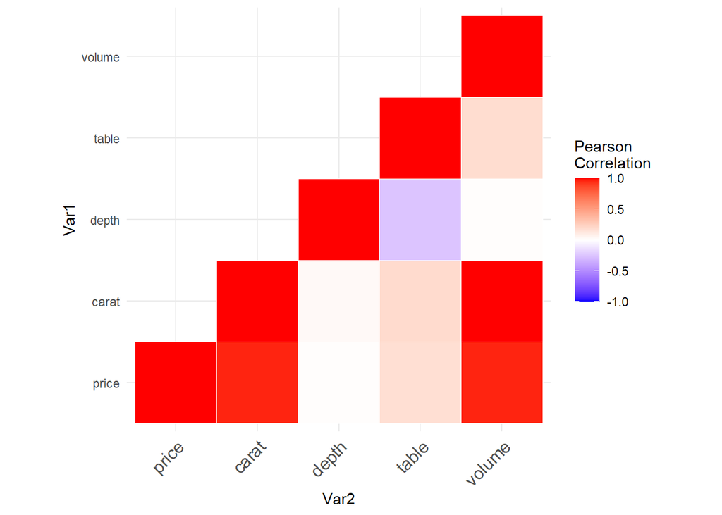

```r
library(ggplot2)
#Creamos una matriz de correlación con los datos descritos
corr.mat<-round(cor(diamonds_df[,c(7,1,5,6,11)], method = "spearman"),2)
#Visualizams los datos mediante un mapa de calor
corr.mat[lower.tri(corr.mat)]<- NA
m.corr.mat<-melt(corr.mat, na.rm=TRUE)

# Fuente: http://www.sthda.com/english/wiki/ggplot2-quick-correlation-matrix-heatmap-r-software-and-data-visualization

ggplot(data = m.corr.mat, aes(Var2, Var1, fill = value))+
 geom_tile(color = "white")+
 scale_fill_gradient2(low = "blue", high = "red", mid = "white",
   midpoint = 0, limit = c(-1,1), space = "Lab",
   name="Pearson\nCorrelation") +
  theme_minimal()+
 theme(axis.text.x = element_text(angle = 45, vjust = 1,
    size = 12, hjust = 1))+
 coord_fixed()
```

Vemos que las variables más correlacionadas con el precio son el peso en kilates y el volumen del diamante. Además, un dato importante que podemos observar es que las variables Profundidad y Tabla son inversamente proporcionales, teniendo una correlación negativa.

Para estas dos variables, vamos a estudiar una a una su índice de correlación:

```r
library(psych)
```

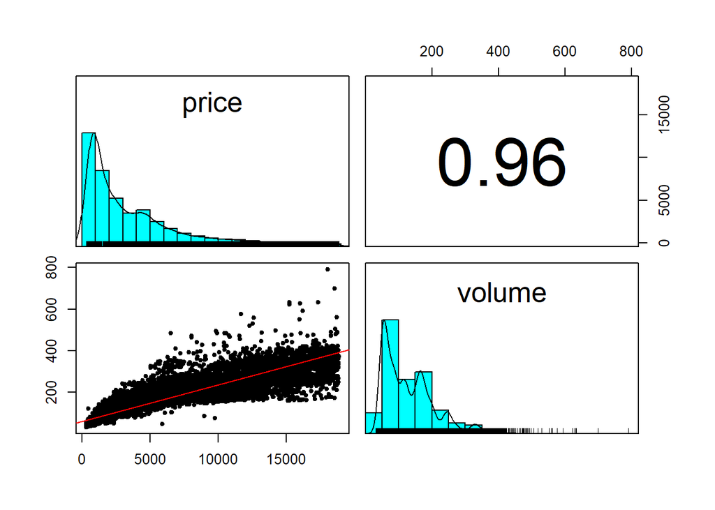

```r
pairs.panels(diamonds_df[,c(7,11)], ellipses = FALSE, lm=TRUE, method = "spearman")
```

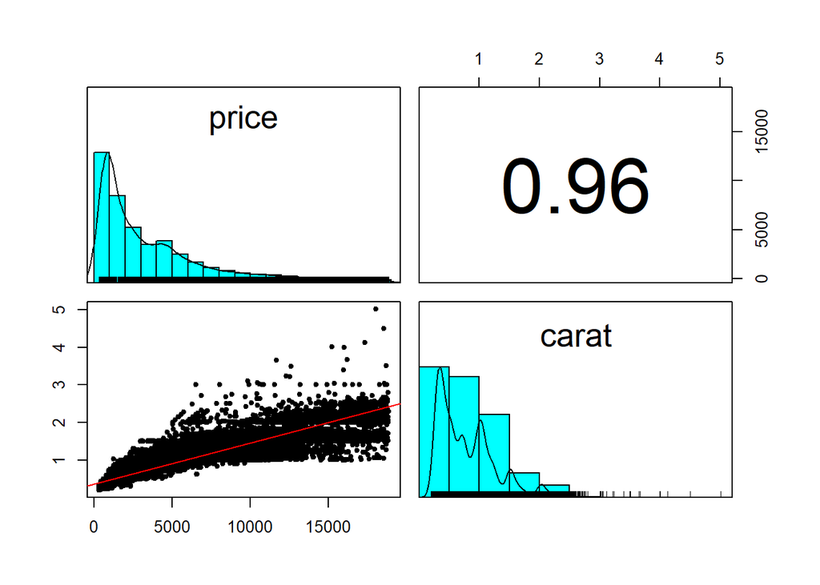

```r
pairs.panels(diamonds_df[,c(7,1)], ellipses = FALSE, lm=TRUE, method = "spearman")
```

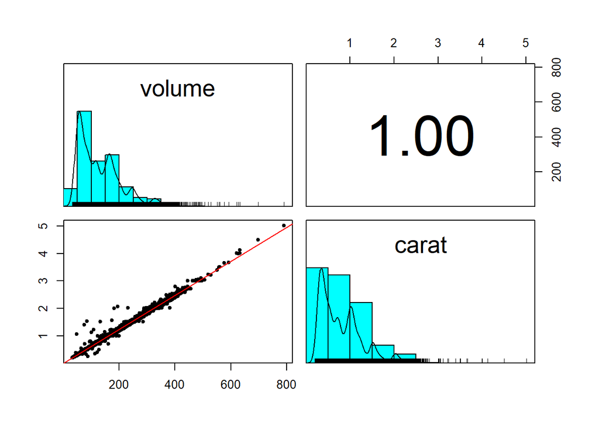

```r
pairs.panels(diamonds_df[,c(11,1)], ellipses = FALSE, lm=TRUE, method = "spearman")
```

Vemos que la correlación entre el Precio y el Peso, y entre el Precio y su volumen es bastante alta.

Los resulados del análisis son:

- Precio y Peso están altamente relacionados
- Precio y Volumen están altamente relacionados
- Peso y Volumen están totalmente relacionados, esto puede ser causa de multicolinealidad, se estudiará más adelante.
- Tabla y Profundidad están inversamente relacionados
- El resto de variables no tienen una relación evidente.

##### 4.3.1.2. Variables Categóricas

**Métodos Chi-square y Cramer-V**

A continuación, vamos a realizar un estudio de correlación para variables categóricas utilizando el test chi-square, para ello, en primer lugar, tenemos que crear una tabla de frecuencias de las variables y luego estudiar su relación mediante dicho test.

Pero antes, debemos discretizar la variable precio. lo haremos mediante divisiones en función de la frecuencia, para tener grupos lo más parecidos posibles, tendremos 4 niveles de precio:

- Primer cuartil: Bajo
- Segundo cuartil: Medio-bajo
- Tercer cuartil: Medio-alto
- Tercer cuartil: Alto

```r
suppressWarnings(suppressMessages(library(arules)))
library(arules)
cuartil.price<-discretize(diamonds_df$price, method="frequency",breaks=4,labels=c("Bajo","Medio-Bajo","Medio-Alto","Alto"))
table(cuartil.price)
```

```
## cuartil.price
##       Bajo Medio-Bajo Medio-Alto       Alto
##      13442      13432      13467      13448
```

Una vez realizada la discretización, procedemos a crear las tablas de contingencia para ver la relación entre el Precio y las variables cualitativas.

```r
#Variable "cut"
tbl.cut<-table(cuartil.price,diamonds_df$cut)
tbl.cut
```

```
##
## cuartil.price Fair Good Ideal Premium Very Good
##    Bajo         88 1055  6275    2900      3124
##    Medio-Bajo  457 1080  6318    3053      2524
##    Medio-Alto  664 1636  4296    3496      3375
##    Alto        387 1120  4598    4298      3045
```

```r
#Variable "Color"
tbl.color<-table(cuartil.price,diamonds_df$color)
tbl.color
```

```
##
## cuartil.price    D    E    F    G    H    I    J
##    Bajo       1868 2784 2263 2906 2011 1184  426
##    Medio-Bajo 2038 2971 2616 2951 1445  887  524
##    Medio-Alto 1699 2467 2533 2225 2303 1454  786
##    Alto       1150 1551 2107 3180 2512 1882 1066
```

```r
#Variable "Clarity"
tbl.clarity<-table(cuartil.price,diamonds_df$clarity)
tbl.clarity
```

```
##
## cuartil.price   I1   IF  SI1  SI2  VS1  VS2 VVS1 VVS2
##    Bajo         55  614 2920 1023 2289 3375 1388 1778
##    Medio-Bajo  189  729 2847 1512 2178 3100 1352 1525
##    Medio-Alto  318  171 4121 4097 1437 2197  458  668
##    Alto        178  270 3143 2517 2250 3556  449 1085
```

Donde, de manera visual, parece dificil establecer relaciones entre el Precio y el resto de las variables.

A continuación, realizamos los tests chi-square para cada una de las tablas, con el fin de comprobar si existe relación.

```r
chisq.test(cuartil.price, diamonds_df$cut)
```

```
##
##  Pearson's Chi-squared test
##
## data:  cuartil.price and diamonds_df$cut
## X-squared = 1730.9, df = 12, p-value < 2.2e-16
```

```r
#chisq.test(tbl.clarity)
#chisq.test(tbl.color)
```

Alternativa utilizando el método V de Cramer, este método da un valor entre 0 y 1, donde 0 es nada relacionado y 1 totalmente relacionado

```r
suppressWarnings(suppressMessages(library(rcompanion)))
library(rcompanion)
cramerV(cuartil.price, diamonds_df$cut)
```

```
## Cramer V
##   0.1036
```

```r
cramerV(cuartil.price, diamonds_df$color)
```

```
## Cramer V
##   0.1131
```

```r
cramerV(cuartil.price, diamonds_df$clarity)
```

```
## Cramer V
##   0.1845
```

Y vemos que no podemos establecer una relación directa entre el Precio y las variables de Color, Corte y Claridad.

**Método Kruskal-Wallis**

A continuación, vamos a utilizar el método Kruskal-Wallis con el fin de no parametrizar la variable “Precio”, y vemos su posible relación con el resto de variables categóricas:

```r
kruskal.test(price~cut, data = diamonds_df)
```

```
##
##  Kruskal-Wallis rank sum test
##
## data:  price by cut
## Kruskal-Wallis chi-squared = 960.33, df = 4, p-value < 2.2e-16
```

```r
kruskal.test(price~color, data = diamonds_df)
```

```
##
##  Kruskal-Wallis rank sum test
##
## data:  price by color
## Kruskal-Wallis chi-squared = 1325.3, df = 6, p-value < 2.2e-16
```

```r
kruskal.test(price~clarity, data = diamonds_df)
```

```
##
##  Kruskal-Wallis rank sum test
##
## data:  price by clarity
## Kruskal-Wallis chi-squared = 2695.5, df = 7, p-value < 2.2e-16
```

**Otros Analisis de relación de variables categóricas**

```r
cramerV(diamonds_df$color, diamonds_df$carat)
```

```
## Cramer V
##   0.1747
```

```r
cramerV(diamonds_df$color, diamonds_df$clarity)
```

```
## Cramer V
##  0.07948
```

```r
kruskal.test(carat~cut, data = diamonds_df)
```

```
##
##  Kruskal-Wallis rank sum test
##
## data:  carat by cut
## Kruskal-Wallis chi-squared = 1757.7, df = 4, p-value < 2.2e-16
```

#### 4.3.2. Contraste de Hipótesis

Vamos a investigar si el precio medio de los diamantes con tipo de corte Premium es igual al de tipo de corte Good

###### Escribimos la hipótesis nula y la hipótesis alternativa

La Hipótesis nula sería que la esperanza de ambas muestras sean iguales y la Hipótesis alternativa H1 que la esperanza de ambas muestras sea diferente, por lo tanto es bilateral

Ho: u1=u2 H1: u1$\neq$u2

```r
#Nivel de significacion
alpha<-1-0.95
hipdiamonds_df<-diamonds_df[diamonds_df$cut=="Good" | diamonds_df$cut=="Premium", ]
#Datos de Good
dfGood <- diamonds_df[diamonds_df$cut=="Good",]
nGood <- nrow(dfGood)
nGood
```

```
## [1] 4891
```

```r
medGood <- mean(dfGood$ price)
sdGood <- sd(dfGood$ price)
#Datos de Premium
dfPremium <- diamonds_df[diamonds_df$cut=="Premium",]
nPremium <- nrow(dfPremium)
medPremium <- mean(dfPremium$ price)
sdPremium <- sd(dfPremium$ price)
s<- sqrt(((nGood-1)*sdGood^2+(nPremium-1)*sdPremium^2)/(nGood+nPremium-2))
s
```

```
## [1] 4180.785
```

```r
sx<- s*sqrt(1/nGood + 1/nPremium)
sx
```

```
## [1] 69.60728
```

```r
#Calculo de t
t<-(medGood-medPremium)/sx
t
```

```
## [1] -9.536733
```

```r
#Calculo el valor crítico
tcritico<-qt((1-alpha/2),df=nGood+nPremium-2)
tcritico
```

```
## [1] 1.960091
```

```r
#Calculo el pvalue
pvalue<-2*(1- (pt(abs(t),df=nGood+nPremium-2)))
pvalue
```

```
## [1] 0
```

```r
#Aplicaré el test Wilcox para verificar que las medias son diferentes
res <- wilcox.test(dfGood$ price, dfPremium$ price, paired = F)
res
```

```
##
##  Wilcoxon rank sum test with continuity correction
##
## data:  dfGood$price and dfPremium$price
## W = 31296504, p-value = 6.744e-13
## alternative hypothesis: true location shift is not equal to 0
```

```r
res$p.value
```

```
## [1] 6.743803e-13
```

El valor de pvalue es 0 es muy inferior al nivel de significación, por lo tanto, rechazamos la hipótesis nula, ya que la esperanza del precio medio es diferente entre ambos tipos de corte. Con respecto al valor crítico expresa el mismo resultado: el valor crítico es -1.96 hasta 1.96 y el valor del estadístico t es de -9 que está totalmente fuera de este intervalo, estamos muy alejados de la zona de aceptación de la Hipótesis nula. Después de ver los resultados, a través del p value y de valor crítico, se deduce que hay diferencias significativas en el precio entre los corte Premium y Good.

Hemos realizado la misma prueba con el test wilcox y nos muestra los mismos datos, al ser el p-value muy inferior al nivel de significancia, se rechaza la hipótesis de que ambas medias sean iguales

#### 4.3.3. Regresiones

```r
modelo1<-lm(price~volume, data=diamonds_df)
summary(modelo1)
```

```
##
## Call:
## lm(formula = price ~ volume, data = diamonds_df)
##
## Residuals:
##      Min       1Q   Median       3Q      Max
## -17748.8   -800.3    -22.0    545.2  12598.8
##
## Coefficients:
##               Estimate Std. Error t value Pr(>|t|)
## (Intercept) -2.325e+03  1.301e+01  -178.8   <2e-16 ***
## volume       4.821e+01  8.637e-02   558.2   <2e-16 ***
## ---
## Signif. codes:  0 '***' 0.001 '**' 0.01 '*' 0.05 '.' 0.1 ' ' 1
##
## Residual standard error: 1530 on 53787 degrees of freedom
## Multiple R-squared:  0.8528, Adjusted R-squared:  0.8528
## F-statistic: 3.116e+05 on 1 and 53787 DF,  p-value: < 2.2e-16
```

```r
ds1 <- data.frame(variables="volume", r_squared=summary(modelo1)$r.squared)
```

```r
modelo2<-lm(price~volume+carat, data=diamonds_df)
summary(modelo2)
```

```
##
## Call:
## lm(formula = price ~ volume + carat, data = diamonds_df)
##
## Residuals:
##      Min       1Q   Median       3Q      Max
## -17274.2   -797.0    -23.2    543.9  12538.4
##
## Coefficients:
##              Estimate Std. Error t value Pr(>|t|)
## (Intercept) -2347.457     13.108 -179.09   <2e-16 ***
## volume         71.740      1.876   38.24   <2e-16 ***
## carat       -3801.216    302.736  -12.56   <2e-16 ***
## ---
## Signif. codes:  0 '***' 0.001 '**' 0.01 '*' 0.05 '.' 0.1 ' ' 1
##
## Residual standard error: 1528 on 53786 degrees of freedom
## Multiple R-squared:  0.8532, Adjusted R-squared:  0.8532
## F-statistic: 1.563e+05 on 2 and 53786 DF,  p-value: < 2.2e-16
```

```r
ds2 <- data.frame(variables="volume+carat", r_squared=summary(modelo2)$r.squared)
```

```r
modelo3<-lm(price~volume+carat+clarity, data=diamonds_df)
summary(modelo3)
```

```
##
## Call:
## lm(formula = price ~ volume + carat + clarity, data = diamonds_df)
##
## Residuals:
##      Min       1Q   Median       3Q      Max
## -16588.4   -640.4   -107.7    485.3  11068.2
##
## Coefficients:
##              Estimate Std. Error t value Pr(>|t|)
## (Intercept) -6823.770     49.952 -136.61  < 2e-16 ***
## volume         47.312      1.586   29.82  < 2e-16 ***
## carat         807.859    256.442    3.15  0.00163 **
## clarityIF    5342.712     57.247   93.33  < 2e-16 ***
## claritySI1   3597.553     48.995   73.43  < 2e-16 ***
## claritySI2   2752.849     49.298   55.84  < 2e-16 ***
## clarityVS1   4461.038     50.019   89.19  < 2e-16 ***
## clarityVS2   4246.097     49.244   86.23  < 2e-16 ***
## clarityVVS1  5032.466     52.914   95.11  < 2e-16 ***
## clarityVVS2  5007.498     51.506   97.22  < 2e-16 ***
## ---
## Signif. codes:  0 '***' 0.001 '**' 0.01 '*' 0.05 '.' 0.1 ' ' 1
##
## Residual standard error: 1283 on 53779 degrees of freedom
## Multiple R-squared:  0.8965, Adjusted R-squared:  0.8965
## F-statistic: 5.175e+04 on 9 and 53779 DF,  p-value: < 2.2e-16
```

```r
ds3 <- data.frame(variables="volume+carat+clarity", r_squared=summary(modelo3)$r.squared)
```

```r
modelo4<-lm(price~carat+volume+clarity+color, data=diamonds_df)
summary(modelo4)
```

```
##
## Call:
## lm(formula = price ~ carat + volume + clarity + color, data = diamonds_df)
##
## Residuals:
##      Min       1Q   Median       3Q      Max
## -16583.0   -676.8   -189.9    470.3  10227.3
##
## Coefficients:
##              Estimate Std. Error  t value Pr(>|t|)
## (Intercept) -6617.779     46.886 -141.145  < 2e-16 ***
## carat        1635.296    231.865    7.053 1.77e-12 ***
## volume         44.756      1.434   31.216  < 2e-16 ***
## clarityIF    5555.616     51.841  107.167  < 2e-16 ***
## claritySI1   3670.235     44.296   82.857  < 2e-16 ***
## claritySI2   2713.066     44.563   60.882  < 2e-16 ***
## clarityVS1   4639.524     45.243  102.546  < 2e-16 ***
## clarityVS2   4330.126     44.517   97.269  < 2e-16 ***
## clarityVVS1  5204.741     47.859  108.753  < 2e-16 ***
## clarityVVS2  5085.336     46.565  109.209  < 2e-16 ***
## colorE       -215.967     18.378  -11.751  < 2e-16 ***
## colorF       -314.752     18.572  -16.948  < 2e-16 ***
## colorG       -506.319     18.183  -27.846  < 2e-16 ***
## colorH       -976.496     19.341  -50.487  < 2e-16 ***
## colorI      -1436.906     21.722  -66.149  < 2e-16 ***
## colorJ      -2336.931     26.811  -87.162  < 2e-16 ***
## ---
## Signif. codes:  0 '***' 0.001 '**' 0.01 '*' 0.05 '.' 0.1 ' ' 1
##
## Residual standard error: 1159 on 53773 degrees of freedom
## Multiple R-squared:  0.9155, Adjusted R-squared:  0.9155
## F-statistic: 3.884e+04 on 15 and 53773 DF,  p-value: < 2.2e-16
```

```r
ds4 <- data.frame(variables="volume+carat+clarity+color", r_squared=summary(modelo4)$r.squared)
modelos_text <- rbind(ds1, ds2)
modelos_text <- rbind(modelos_text, ds3)
modelos_text <- rbind(modelos_text, ds4)
```

Para conseguir el modelo óptimo, construimos 4 modelos, a los que hemos ido añdiendo más variables hasta conseguir un modelo óptimo.

Finalmente en el cuarto y último modelo, utilizamos el peso, volumen, la apariencia visual y el color y el coeficiente de determinación da un 0.91. Consideramos que ya es un número bastante alto, además el p-valor es 0, lo que indica que es un buen modelo.

Como prueba, vamos a intentar predecir el precio de un diamante según sus características.

```r
dfPrueba<- data.frame(carat=2.54,volume=400,clarity='SI2',color='I')
predict(modelo4,dfPrueba)
```

```
##        1
## 16714.28
```

La prueba realizada indica que para un peso de 2.54, volumen de 400, apariencia visual SI2 y color I, el modelo predice que el precio sería de 16714.28 dólares.

Ahora realizaremos un estudio de regresión logística, intentaremos predecir si el diamante tiene precio alto en función del peso, volumen En primer lugar reralizaremos un modelo donde tenemos en cuenta el precio alto o no del diamante y también si su peso es alto o no:

```r
diamonds_df$PA<-ifelse(diamonds_df$price>=unname(quantile(diamonds_df$price,.75)),1,0)
diamonds_df$CA<-ifelse(diamonds_df$carat>=unname(quantile(diamonds_df$carat,.75)),1,0)
modelo_logistico_1 <- glm(formula=PA~CA , data = diamonds_df, family = "binomial")
summary (modelo_logistico_1)
```

```
##
## Call:
## glm(formula = PA ~ CA, family = "binomial", data = diamonds_df)
##
## Deviance Residuals:
##     Min       1Q   Median       3Q      Max
## -1.8024  -0.3489  -0.3489   0.6625   2.3788
##
## Coefficients:
##             Estimate Std. Error z value Pr(>|z|)
## (Intercept) -2.76845    0.02122  -130.5   <2e-16 ***
## CA           4.17322    0.03013   138.5   <2e-16 ***
## ---
## Signif. codes:  0 '***' 0.001 '**' 0.01 '*' 0.05 '.' 0.1 ' ' 1
##
## (Dispersion parameter for binomial family taken to be 1)
##
##     Null deviance: 60497  on 53788  degrees of freedom
## Residual deviance: 31646  on 53787  degrees of freedom
## AIC: 31650
##
## Number of Fisher Scoring iterations: 5
```

```r
print(paste0("Valor OR: ",exp(coefficients(modelo_logistico_1)[2])))
```

```
## [1] "Valor OR: 64.9244545611016"
```

En el segundo modelo añadimos el volumen, de tal forma que ahora nuestro modelo tendrá el peso al to o no y el volumen alto o no para predecir si el precio es alto

```r
diamonds_df$VA<-ifelse(diamonds_df$volume>=unname(quantile(diamonds_df$volume,.75)),1,0)
modelo_logistico_2 <- glm(formula=PA~CA+VA , data = diamonds_df, family = "binomial")
summary (modelo_logistico_2)
```

```
##
## Call:
## glm(formula = PA ~ CA + VA, family = "binomial", data = diamonds_df)
##
## Deviance Residuals:
##     Min       1Q   Median       3Q      Max
## -1.8494  -0.3462  -0.3462   0.6316   2.3852
##
## Coefficients:
##             Estimate Std. Error z value Pr(>|z|)
## (Intercept) -2.78456    0.02129 -130.78   <2e-16 ***
## CA           2.22150    0.08562   25.95   <2e-16 ***
## VA           2.07377    0.08578   24.18   <2e-16 ***
## ---
## Signif. codes:  0 '***' 0.001 '**' 0.01 '*' 0.05 '.' 0.1 ' ' 1
##
## (Dispersion parameter for binomial family taken to be 1)
##
##     Null deviance: 60497  on 53788  degrees of freedom
## Residual deviance: 31082  on 53786  degrees of freedom
## AIC: 31088
##
## Number of Fisher Scoring iterations: 5
```

```r
print(paste0("Valor OR: ",exp(coefficients(modelo_logistico_2)[2])))
```

```
## [1] "Valor OR: 9.22117595709824"
```

```r
print(paste0("Valor OR: ",exp(coefficients(modelo_logistico_2)[3])))
```

```
## [1] "Valor OR: 7.95476115565293"
```

Hemos conseguido reducir el valor de AIC, nuestro modelo ha mejorado. Todas las variables tienen importancia en el modelo. Según el modelo, volumen alto y peso alto producen un precio alto en el diamante, para saber si esta afirmación es correcta, realizaremos el test de holem para saber si el modelo está bien ajustado y por otro lado, miraremos al curca ROC y el área bajo la curva para poder afirmar que el volumen y peso alto producen un precio alto.

Intentaremos predecir la probabilidad de tener un precio alto, si el peso y el volumen son altos

```r
df_2<-data.frame (CA=1,VA=1)
predict (modelo_logistico_2, df_2 ,type="response")
```

```
##         1
## 0.8191669
```

Nos da una probabilidad de un 82% de que si el volumen y el peso son altos, el precio también será alto. Realizamos el test de Hoslem para ver el nivel de asjute:

```r
suppressWarnings(suppressMessages(library(ResourceSelection)))
library(ResourceSelection)
hoslem.test(diamonds_df$PA, fitted(modelo_logistico_2))
```

```
##
##  Hosmer and Lemeshow goodness of fit (GOF) test
##
## data:  diamonds_df$PA, fitted(modelo_logistico_2)
## X-squared = 6.1112e-17, df = 8, p-value = 1
```

```r
suppressWarnings(suppressMessages(library(boot)))
library(boot)
cv_error <- cv.glm(data = diamonds_df,glmfit = modelo_logistico_2, K=5)
cv_error$delta
```

```
## [1] 0.08008905 0.08008797
```

El error es muy pequeño, por lo que indica que el modelo es muy bueno

#### 4.3.4. Análisis de multicolinealidad

A continuación, vamos a realizar un estudio sobre la multicolinealidad, siendo ésta, la posible dependencia de unas variables con respecto a otras. En este caso, como hemos estudiado, tenemos una fuerte correlación entre las variables peso y volumen, que al tratarse de diamantes de relativa pureza, la relación entre dichas variables no se vería afectada por posibles residuos en los diamantes. El estudio de multicolinealidad se realiza mediante la raíz cuadrada del resultado de la función “VIF” que encontramos en la librearía “faraway”

```r
suppressWarnings(suppressMessages(library(faraway)))
sqrt(vif(modelo_logistico_2))
```

```
##       CA       VA
## 8.673653 8.614915
```

Con los datos disponibles, vemos que tenemos cierto grado de multicolinealidad, a pesar de ello, consideramos que, debido a que el volumen lo hemos calculado nosotros, con los datos de X, Y y Z, y dicha variable no tiene en cuenta otros factores, se mantendrá la variable Volumen para los calculos anteriores y posteriores.

#### 4.3.5. Árbol de clasificación

Como hemos observado en las secciones anteriores, tenemos una fuerte correlación entre las variables Precio, peso y volumen, por tanto, vamos a realizar un árbol de clasificación basado en esas variables para intentar predecir la categoría de precio del diamante, para ello, vamos a utilizar las categorías que habíamos descrito en el apartado 4.3.1 Para ello, creamos un nuevo dataset con las columnas a utilizar en el análisis y dividir los datos en entrenamiento y test, 2/3 para entrenar y 1/3 para probar.

```r
#Creamos el Data Set
diamonds_tree<-cbind(diamonds_df, cuartil.price)
#Lo desordenamos
diamonds_tree<-diamonds_tree[sample(nrow(diamonds_tree)),]
head(diamonds_tree,10)
```

```
##       carat       cut color clarity depth table price    x    y    z    volume
## 38639  0.53 Very Good     H     SI2  61.4    57  1046 5.21 5.25 3.21  87.80152
## 39317  0.41     Ideal     D     VS2  61.6    55  1076 4.77 4.74 2.93  66.24671
## 35152  0.30 Very Good     G      IF  62.8    57   895 4.27 4.30 2.69  49.39109
## 42230  0.61      Good     I     VS2  63.4    55  1303 5.42 5.46 3.45 102.09654
## 47399  0.55     Ideal     F     VS2  62.1    55  1871 5.27 5.25 3.26  90.19605
## 12549  1.20 Very Good     H     SI2  62.0    58  5280 6.76 6.91 4.24 198.05718
## 39677  0.35     Ideal     F    VVS1  61.3    55  1096 4.55 4.58 2.80  58.34920
## 48926  0.74      Good     J     SI1  59.9    64  2058 5.82 5.86 3.50 119.36820
## 2732   0.71     Ideal     E     VS2  62.5    55  3247 5.67 5.73 3.56 115.66120
## 31997  0.33     Ideal     D     VS2  60.9    55   781 4.47 4.50 2.73  54.91395
##       PA CA VA cuartil.price
## 38639  0  0  0    Medio-Bajo
## 39317  0  0  0    Medio-Bajo
## 35152  0  0  0          Bajo
## 42230  0  0  0    Medio-Bajo
## 47399  0  0  0    Medio-Bajo
## 12549  0  1  1    Medio-Alto
## 39677  0  0  0    Medio-Bajo
## 48926  0  0  0    Medio-Bajo
## 2732   0  0  0    Medio-Alto
## 31997  0  0  0          Bajo
```

```r
#Dividimos los datos de entrenamiento y test
indexes = sample(1:nrow(diamonds_tree), size=floor((2/3)*nrow(diamonds_tree)))
diamonds_train<-diamonds_tree[indexes,]
diamonds_test<-diamonds_tree[-indexes,]
```

A continuación, modelamos el árbol:

```r
library(rpart)
```

```r
library(rpart.plot)
#Modelado
model.tree <- rpart(formula = cuartil.price ~ carat+volume , data = diamonds_train, method = "class")
model.tree
```

```
## n= 35859
##
## node), split, n, loss, yval, (yprob)
##       * denotes terminal node
##
## 1) root 35859 26803 Bajo (0.2525446889 0.2481943166 0.2505647118 0.2486962827)
##   2) volume< 112.2591 17174  8120 Bajo (0.5271922674 0.4443344591 0.0282403633 0.0002329102)
##     4) volume< 65.94332 9376  1390 Bajo (0.8517491468 0.1482508532 0.0000000000 0.0000000000) *
##     5) volume>=65.94332 7798  1557 Medio-Bajo (0.1369581944 0.8003334188 0.0621954347 0.0005129520) *
##   3) volume>=112.2591 18685  9771 Alto (0.0001070377 0.0679154402 0.4549103559 0.4770671662)
##     6) volume< 190.4626 12092  4102 Medio-Alto (0.0001653986 0.1048627192 0.6607674496 0.2342044327) *
##     7) volume>=190.4626 6593   511 Alto (0.0000000000 0.0001516760 0.0773547702 0.9224935538) *
```

```r
#Reglas aplicadas
rpart.rules(model.tree)
```

```
##  cuartil.price  Baj Med Med Alt
##           Bajo [.85 .15 .00 .00] when volume <   66
##     Medio-Bajo [.14 .80 .06 .00] when volume is  66 to 112
##     Medio-Alto [.00 .10 .66 .23] when volume is 112 to 190
##           Alto [.00 .00 .08 .92] when volume >=        190
```

También comprobamos la bondad del modelo del árbol de clasificación utilizando los datos de test que habíamos reservado y los comparamos con los orignales mediante una matriz de confusión.

```r
suppressWarnings(suppressMessages(library(caret)))
prediccion_1 <- predict(model.tree, newdata = diamonds_test, type = "class")
confusionMatrix(prediccion_1, diamonds_test[["cuartil.price"]])
```

```
## Confusion Matrix and Statistics
##
##             Reference
## Prediction   Bajo Medio-Bajo Medio-Alto Alto
##   Bajo       3868        675          0    1
##   Medio-Bajo  517       3173        240    1
##   Medio-Alto    1        684       3953 1443
##   Alto          0          0        289 3085
##
## Overall Statistics
##
##                Accuracy : 0.7852
##                  95% CI : (0.7791, 0.7912)
##     No Information Rate : 0.2528
##     P-Value [Acc > NIR] : < 2.2e-16
##
##                   Kappa : 0.7137
##
##  Mcnemar's Test P-Value : < 2.2e-16
##
## Statistics by Class:
##
##                      Class: Bajo Class: Medio-Bajo Class: Medio-Alto
## Sensitivity               0.8819            0.7001            0.8820
## Specificity               0.9501            0.9434            0.8418
## Pos Pred Value            0.8512            0.8072            0.6501
## Neg Pred Value            0.9613            0.9029            0.9554
## Prevalence                0.2446            0.2528            0.2500
## Detection Rate            0.2157            0.1770            0.2205
## Detection Prevalence      0.2534            0.2192            0.3392
## Balanced Accuracy         0.9160            0.8218            0.8619
##                      Class: Alto
## Sensitivity               0.6810
## Specificity               0.9784
## Pos Pred Value            0.9143
## Neg Pred Value            0.9007
## Prevalence                0.2526
## Detection Rate            0.1721
## Detection Prevalence      0.1882
## Balanced Accuracy         0.8297
```

Podemos observar que tenemos muy buenos valores de “Accuracy” y “Kappa”.

## 4.4. Exportación de los datos tratados

Finalmente, vamos a exportar a un archivo .CSV el dataset sobre el que hemos estado trabajando.

```r
write.csv(diamonds_df,"diamonds_processed.csv", row.names = TRUE)
```

## 5. Representación de los resultados a partir de tablas y gráficas.

### Correlaciones

En primer lugar, antes de realizar el análisis medimos la correlación de las distintas variables del dataset para ver qué variables son susceptibles de ser estudiadas y también la relación que hay entre ellas, dejamos representada el mapa de calor de las diferentes variables numéricas mediante el test de Spearman:

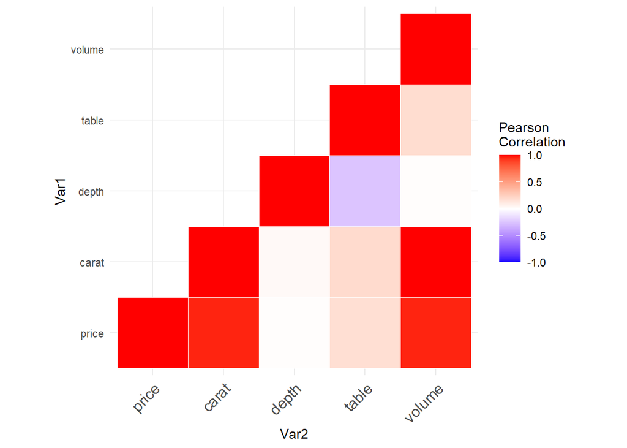

```r
ggplot(data = m.corr.mat, aes(Var2, Var1, fill = value))+
 geom_tile(color = "white")+
 scale_fill_gradient2(low = "blue", high = "red", mid = "white",
   midpoint = 0, limit = c(-1,1), space = "Lab",
   name="Pearson\nCorrelation") +
  theme_minimal()+
 theme(axis.text.x = element_text(angle = 45, vjust = 1,
    size = 12, hjust = 1))+
 coord_fixed()
```

### Regresiones

Hemos realizado modelos de regresión lineal y logístico para intentar predecir el precio de mercado de un diamante según sus características. En el modelo lineal, elegimos como primer modelo solo la variable volume y posteriormente fuimos adaptando el modelo, añadiendo nuevas variables hasta conseguir el modelo final. El modelo final contiene la combinación de las características: carat+volume+clarity+color, este modelo nos muestra ya de por si más un 90% de la variabilidad de los datos

```r
suppressWarnings(suppressMessages(library(knitr)))

options (knitr.kable.NA = '')
kable( modelos_text[,c("variables","r_squared")],digits=2,caption="Modelos lineales" )
```

Modelos lineales

| variables | r_squared |
| --- | --- |
| volume | 0.85 |
| volume+carat | 0.85 |
| volume+carat+clarity | 0.90 |
| volume+carat+clarity+color | 0.92 |

Con respecto al modelo logístico, intentamos ver si somos capacacer de predecir si un diamante es caro o no si el volumen o peso del mismo son altos.

```r
modelo_logistico_2 <- glm(formula=PA~CA+VA , data = diamonds_df, family = "binomial")
```

El ajuste del modelo es bueno, pero para poder demostrar si es correcto, dibujamos la curva ROC para evaluar la calidad del ajuste

```r
suppressWarnings(suppressMessages(library(pROC)))
library (pROC)
prob_p_alto= predict(modelo_logistico_2, diamonds_df, type="response")
g= roc(diamonds_df$PA, prob_p_alto, data=diamonds_df)
```

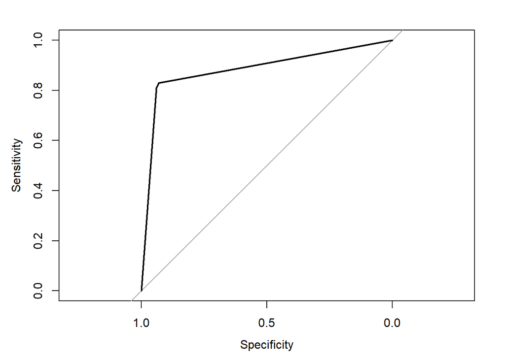

```r
plot (g)
```

```r
auc (g)
```

```
## Area under the curve: 0.8831
```

El área bajo la curva es de 0.88, es un valor bastante alto. Por lo tanto podemos afirmar que el precio alto está ligado a un volumen alto y peso alto.

### Arbol de decisión

Intentamos predecir la cateoría del precio del diamante según el volumen / carat del mismo. Para ello construimos un modelo basado en un árbol de clasificación, la representación del modelo es

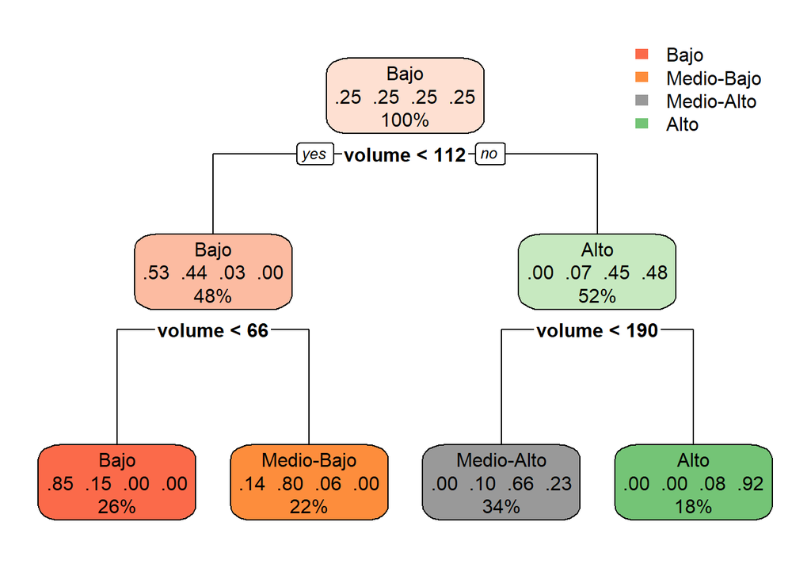

```r
rpart.plot(model.tree)
```

## 6. Resolución del problema. A partir de los resultados obtenidos, ¿cuáles son las conclusiones? ¿Los resultados permiten responder al problema?

Por tanto, respecto a la cuestión inicial de poder comprobar y medir las relaciones entre las características (tanto físicas como las subjetivas) de un diamante y su precio, después de realizar todos los análisis, podemos afirmar que se han obtenido resultados variados:

> Podemos afirmar, con los datos inciales y su posterior análisis, que se ha podido responder a la cuestión inicial de la que partía el estudio: comprobar las relaciones entre las características físicas y subjetivas de un diamante y su precio, pudiendo, además, cuantificar y crear modelos de clasificación y predicción basados en esas relaciones.

## Anexo A. Tabla de contribuciones

A continuación se añade la tabla de contribuciones, firmada mediante las iniciales de los contribuyentes:

- APAV: Anddy Paúl Aldave Valle
- AJPD: Alejandro Javier Pulido Duque

| **Contribuciones** | **Firma** |
| --- | --- |
| Investigación previa | APAV, AJPD |
| Redacción de las respuestas | APAV, AJPD |
| Desarrollo del código | APAV, AJPD |